# World Energy EDA: Economic Development and Environmental Cost (2000–2024)

## Research Problem Statement

Despite rapid economic growth in the 21st century, it remains unclear whether wealthier nations are successfully decoupling GDP growth from greenhouse gas emissions, or whether higher economic output continues to drive proportionally higher energy consumption and environmental impact — a gap that critically undermines the formulation of effective climate policy and sustainable development targets.

## Research Questions

**RQ1:** Is there a statistically significant positive relationship between a **country's GDP** and its **primary energy consumption and greenhouse gas emissions** over the period 2000–2024?

**RQ2:** Do the **top 10 highest-GDP countries** show a different **emissions-to-energy trend** compared to the **bottom 10 lowest-GDP countries** over the same period?

## Research Objectives

1. To perform systematic data quality assessment on the World Energy dataset and justify the selection of the 2000–2024 scope based on data completeness evidence.
2. To identify the strongest correlated variable triplet (GDP, energy, emissions) as the analytical scope through exploratory correlation analysis.

## EDA Workflow

```
Raw data (23,195 rows × 130 cols)
    │
    ├─ Step 1: Load & Inspect
    ├─ Step 2: Data Quality Checks
    ├─ Step 3: Classify entities (country vs aggregate)
    ├─ Step 4: Scope selection — Time period justification
    ├─ Step 5: Scope selection — Variable selection via correlation
    ├─ Step 6: Data cleaning & imputation
    ├─ Step 7: Post-clean validation
    ├─ Step 8: Univariate analysis
    ├─ Step 9: Bivariate & relationship analysis
    ├─ Step 10: Group comparison (Top 10 vs Bottom 10 GDP)
    └─ Step 11: Summary & conclusions
```

## Step 1: Import Libraries & Load Data

```python
import pandas as pd
import numpy as np
import matplotlib.pyplot as plt
import matplotlib.ticker as mticker
import seaborn as sns
import warnings

warnings.filterwarnings('ignore')

# Global visual style
sns.set_theme(style='whitegrid', palette='tab10')
plt.rcParams.update({
    'figure.dpi': 110,
    'axes.titlesize': 13,
    'axes.labelsize': 11,
    'xtick.labelsize': 9,
    'ytick.labelsize': 9,
})

print("Libraries loaded successfully.")
```

```
Libraries loaded successfully.
```

```python
# ── Update path if needed ──────────────────────────────────────────────────
CSV_PATH = r'WorldEnergy.csv'
# ───────────────────────────────────────────────────────────────────────────

df_raw = pd.read_csv(CSV_PATH)

print(f"Dataset loaded: {df_raw.shape[0]:,} rows × {df_raw.shape[1]} columns")
print(f"Year range    : {int(df_raw['year'].min())} – {int(df_raw['year'].max())}")
print(f"Entities      : {df_raw['country'].nunique()} unique")
df_raw.head(3)
```

```
Dataset loaded: 23,195 rows × 130 columns
Year range    : 1900 – 2024
Entities      : 314 unique
```

|  | country | year | iso_code | population | gdp | biofuel_cons_change_pct | biofuel_cons_change_twh | biofuel_cons_per_capita | biofuel_consumption | biofuel_elec_per_capita | ... | solar_share_elec | solar_share_energy | wind_cons_change_pct | wind_cons_change_twh | wind_consumption | wind_elec_per_capita | wind_electricity | wind_energy_per_capita | wind_share_elec | wind_share_energy |
| --- | --- | --- | --- | --- | --- | --- | --- | --- | --- | --- | --- | --- | --- | --- | --- | --- | --- | --- | --- | --- | --- |
| 0 | ASEAN (Ember) | 2000 | NaN | NaN | NaN | NaN | NaN | NaN | NaN | NaN | ... | 0.0 | NaN | NaN | NaN | NaN | NaN | 0.0 | NaN | 0.0 | NaN |
| 1 | ASEAN (Ember) | 2001 | NaN | NaN | NaN | NaN | NaN | NaN | NaN | NaN | ... | 0.0 | NaN | NaN | NaN | NaN | NaN | 0.0 | NaN | 0.0 | NaN |
| 2 | ASEAN (Ember) | 2002 | NaN | NaN | NaN | NaN | NaN | NaN | NaN | NaN | ... | 0.0 | NaN | NaN | NaN | NaN | NaN | 0.0 | NaN | 0.0 | NaN |

3 rows × 130 columns

## Step 2: Raw Data Quality Checks

**Rationale:** Check for quality of raw data, checking duplicates and year ranges

> **Gap in Makai's notebook:** Quality checks were skipped entirely on the raw data. Duplicate detection, year range validation, and string anomaly checks were missing. **Gap in Notebook A (Desmond Kan):** Quality checks existed but were run after filtering, missing issues in the raw data.

We check for: (1) duplicates, (2) year range validity, (3) structural entity classification, (4) overall missingness pattern.

```python
# ── 2.1 Duplicate check ────────────────────────────────────────────────────
n_full_dup   = df_raw.duplicated().sum()
n_key_dup    = df_raw.duplicated(subset=['country', 'year']).sum()

print("=== Duplicate Check ===")
print(f"  Fully duplicate rows         : {n_full_dup}")
print(f"  Duplicate (country, year) pairs: {n_key_dup}")
if n_key_dup == 0:
    print("  ✅ No duplicate entries — each country-year pair is unique.")
else:
    print("  ⚠️  Duplicates found — investigation needed.")
```

```
=== Duplicate Check ===
  Fully duplicate rows         : 0
  Duplicate (country, year) pairs: 0
  ✅ No duplicate entries — each country-year pair is unique.
```

```python
# ── 2.2 Year range sanity check ────────────────────────────────────────────
invalid_yr = df_raw[(df_raw['year'] < 1900) | (df_raw['year'] > 2025)]
print("=== Year Range Check ===")
print(f"  Expected: 1900–2024")
print(f"  Actual  : {int(df_raw['year'].min())} – {int(df_raw['year'].max())}")
print(f"  Rows outside valid range: {len(invalid_yr)}")
if len(invalid_yr) == 0:
    print("  ✅ All years within expected range.")
```

```
=== Year Range Check ===
  Expected: 1900–2024
  Actual  : 1900 – 2024
  Rows outside valid range: 0
  ✅ All years within expected range.
```

```python
# ── 2.3 Overall missingness — top 15 columns ───────────────────────────────
missing_all = (df_raw.isnull().sum() / len(df_raw) * 100).sort_values(ascending=False)

print("=== Top 15 Columns by Missing % (raw dataset) ===")
print(missing_all.head(15).to_string())

# Severity bucketing
def miss_severity(pct):
    if pct == 0:       return 'Complete (0%)'
    elif pct <= 20:    return 'Low (<20%)'
    elif pct <= 50:    return 'Moderate (20-50%)'
    elif pct <= 80:    return 'High (50-80%)'
    else:              return 'Very High (>80%)'

buckets = missing_all.apply(miss_severity).value_counts()
print()
print("=== Missingness Severity Buckets ===")
print(buckets.to_string())
```

```
=== Top 15 Columns by Missing % (raw dataset) ===
biofuel_cons_change_pct               91.075663
solar_cons_change_pct                 89.157146
nuclear_cons_change_pct               88.881224
wind_cons_change_pct                  87.937055
other_renewables_cons_change_pct      82.806639
electricity_share_energy              80.965725
low_carbon_energy_per_capita          77.818495
oil_energy_per_capita                 77.818495
coal_cons_per_capita                  77.818495
fossil_energy_per_capita              77.818495
gas_energy_per_capita                 77.818495
hydro_energy_per_capita               77.818495
other_renewables_energy_per_capita    77.818495
renewables_energy_per_capita          77.818495
solar_energy_per_capita               77.818495

=== Missingness Severity Buckets ===
High (50-80%)        107
Moderate (20-50%)     14
Very High (>80%)       6
Complete (0%)          2
Low (<20%)             1
```

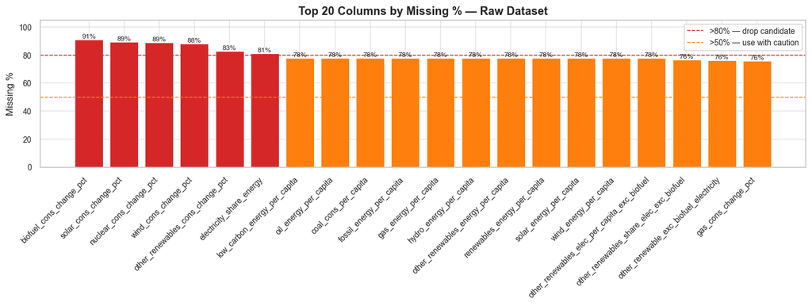

```python
# ── 2.4 Missingness bar chart (top 20 columns) ─────────────────────────────
top20_miss = missing_all.head(20)
colors = ['#d62728' if v > 80 else '#ff7f0e' if v > 50 else '#f7b731' if v > 20 else '#2ca02c'
          for v in top20_miss.values]

fig, ax = plt.subplots(figsize=(13, 5))
bars = ax.bar(top20_miss.index, top20_miss.values, color=colors, edgecolor='white', linewidth=0.5)
ax.axhline(80, color='#d62728', linestyle='--', linewidth=1, label='>80% — drop candidate')
ax.axhline(50, color='#ff7f0e', linestyle='--', linewidth=1, label='>50% — use with caution')
ax.set_title('Top 20 Columns by Missing % — Raw Dataset', fontweight='bold')
ax.set_ylabel('Missing %')
ax.set_ylim(0, 105)
ax.legend(fontsize=9)
plt.xticks(rotation=45, ha='right')
for bar, val in zip(bars, top20_miss.values):
    ax.text(bar.get_x() + bar.get_width()/2, bar.get_height() + 1,
            f'{val:.0f}%', ha='center', fontsize=8)
plt.tight_layout()
plt.show()
```

## Step 3: Classify Entities — Countries vs Regional Aggregates

**Rationale:** The dataset contains 314 unique entities, but not all are sovereign countries. Rows like `"Africa (Ember)"`, `"Asia (EIA)"`, and `"World"` are regional or source-specific aggregates. If included in country-level analysis, they will double-count emissions and energy figures (e.g. "Asia" already contains China, India, Japan).

**Method:** Rows with a valid 3-character ISO 3166-1 alpha-3 code (`iso_code`) are sovereign countries. Rows without an ISO code are aggregates.

> **This step was correct in Makai's notebook** and is retained here.

```python
real_countries     = df_raw[df_raw['iso_code'].notna() & (df_raw['iso_code'].str.len() == 3)].copy()
aggregate_regions  = df_raw[df_raw['iso_code'].isna() | (df_raw['iso_code'] == '')].copy()

print(f"Real countries      : {real_countries['country'].nunique()}")
print(f"Aggregate/regional  : {aggregate_regions['country'].nunique()}")
print()
print("Sample aggregate entities (first 15):")
print(list(aggregate_regions['country'].unique()[:15]))
```

```
Real countries      : 220
Aggregate/regional  : 94

Sample aggregate entities (first 15):
['ASEAN (Ember)', 'Africa', 'Africa (EI)', 'Africa (EIA)', 'Africa (Ember)', 'Africa (Shift)', 'Asia', 'Asia & Oceania (EIA)', 'Asia (Ember)', 'Asia Pacific (EI)', 'Asia and Oceania (Shift)', 'Australia and New Zealand (EIA)', 'CIS (EI)', 'Central & South America (EIA)', 'Central America (EI)']
```

## Step 4: Time Period Scope Selection — Justification

**Rationale:** The full dataset spans 1900–2024 (124 years), but data quality degrades significantly before 2000. We use evidence from the data itself to justify restricting to **2000–2024**.

Three lines of evidence support this decision:

1. **Greenhouse gas emissions data** is entirely absent before 2000 (100% missing pre-2000).
2. **GDP data** is ~49% missing pre-2000 vs ~30% post-2000 — already borderline, but usable.
3. **Primary energy consumption** is 57.6% missing pre-2000 vs only 1.8% post-2000.

Any analysis spanning pre-2000 years would require imputing majority-missing columns — introducing more noise than signal. The **2000–2024 window** is the largest range with acceptable data completeness for all three core variables.

```python
# ── Evidence: missing rate pre-2000 vs post-2000 for the three core variables ─
trio_cols = ['gdp', 'primary_energy_consumption', 'greenhouse_gas_emissions']

pre  = df_raw[df_raw['year'] < 2000]
post = real_countries[real_countries['year'] >= 2000]

print("=" * 62)
print(f"{'Column':<35} {'Pre-2000 Missing':>15} {'Post-2000 Missing':>15}")
print("=" * 62)
for col in trio_cols:
    pre_pct  = pre[col].isna().mean() * 100
    post_pct = post[col].isna().mean() * 100
    flag = '✅' if post_pct < 30 else '⚠️'
    print(f"{col:<35} {pre_pct:>14.1f}% {post_pct:>14.1f}% {flag}")
print("=" * 62)
print()
print("Decision: Restrict to 2000–2024.")
print("Justification: All three core variables drop from majority-missing")
print("(>49%) to minority-missing (<30%) in the post-2000 window.")
```

```
==============================================================
Column                              Pre-2000 Missing Post-2000 Missing
==============================================================
gdp                                           49.3%           29.6% ✅
primary_energy_consumption                    57.6%            1.8% ✅
greenhouse_gas_emissions                     100.0%            4.4% ✅
==============================================================

Decision: Restrict to 2000–2024.
Justification: All three core variables drop from majority-missing
(>49%) to minority-missing (<30%) in the post-2000 window.
```

```python
# ── Apply the time scope ───────────────────────────────────────────────────
START_YEAR, END_YEAR = 2000, 2024

rc_scoped = real_countries[(real_countries['year'] >= START_YEAR) &
                            (real_countries['year'] <= END_YEAR)].copy()

print(f"Scoped dataset: {rc_scoped.shape[0]:,} rows × {rc_scoped.shape[1]} columns")
print(f"Countries     : {rc_scoped['country'].nunique()}")
print(f"Year range    : {int(rc_scoped['year'].min())} – {int(rc_scoped['year'].max())}")
```

```
Scoped dataset: 5,383 rows × 130 columns
Countries     : 220
Year range    : 2000 – 2024
```

## Step 5: Variable Selection — Correlation-Driven Scope Narrowing

**Rationale:** The scoped dataset still has 130 columns, most of which are energy sub-categories (coal, solar, wind, nuclear, etc.). Rather than arbitrarily picking variables, we use a **data-driven approach**: compute a correlation matrix on columns with acceptable completeness (≤50% missing), identify the highest-correlated cluster, and use that cluster as our analytical scope.

**Expected outcome:** Economic size (GDP), energy consumption, and emissions form a tight high-correlation cluster — which we then use as the research focus.

> **This logic was Makai's key contribution** and is the strongest part of that notebook. Retained and made explicit here.

```python
# ── Select numeric columns with ≤50% missing ───────────────────────────────
numeric_cols = rc_scoped.select_dtypes(include=np.number).columns.tolist()
miss_pct_scoped = (rc_scoped[numeric_cols].isnull().mean() * 100)
cols_to_keep = miss_pct_scoped[miss_pct_scoped <= 50].index.tolist()

print(f"Numeric columns total         : {len(numeric_cols)}")
print(f"Columns with ≤50% missing     : {len(cols_to_keep)}")
print(f"Dropped (>50% missing)        : {len(numeric_cols) - len(cols_to_keep)}")
```

```
Numeric columns total         : 128
Columns with ≤50% missing     : 64
Dropped (>50% missing)        : 64
```

```python
# ── Pearson correlation matrix on retained columns ─────────────────────────
corr_matrix = rc_scoped[cols_to_keep].corr(method='pearson')

# Top 10 strongest positive pairs (excluding self-correlations)
pairs = (corr_matrix.unstack()
         .reset_index()
         .rename(columns={'level_0': 'Var1', 'level_1': 'Var2', 0: 'Correlation'}))
pairs = pairs[pairs['Var1'] < pairs['Var2']].sort_values('Correlation', ascending=False)

print("Top 10 strongest correlated pairs (Pearson r):")
print(pairs.head(10).to_string(index=False))
```

```
Top 10 strongest correlated pairs (Pearson r):
                  Var1                        Var2  Correlation
    electricity_demand      electricity_generation     0.999858
    fossil_electricity    greenhouse_gas_emissions     0.995529
    electricity_demand  primary_energy_consumption     0.989650
    electricity_demand          fossil_electricity     0.989497
electricity_generation  primary_energy_consumption     0.989436
electricity_generation          fossil_electricity     0.989078
    fossil_electricity  primary_energy_consumption     0.986419
   biofuel_electricity other_renewable_electricity     0.982538
      coal_electricity    greenhouse_gas_emissions     0.981689
 hydro_elec_per_capita  renewables_elec_per_capita     0.981574
```

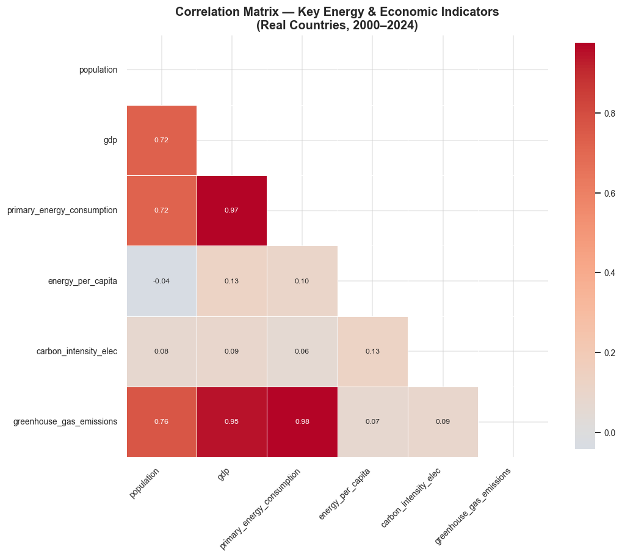

```python
# ── Focused heatmap: key energy & economic indicators ───────────────────────
key_features = [
    'population', 'gdp', 'primary_energy_consumption', 'energy_per_capita',
    'renewables_share_energy', 'fossil_share_energy', 'coal_share_energy',
    'carbon_intensity_elec', 'greenhouse_gas_emissions',
    'solar_share_energy', 'wind_share_energy', 'hydro_share_energy', 'nuclear_share_energy'
]
key_features = [c for c in key_features if c in cols_to_keep]
corr_subset = rc_scoped[key_features].corr()

fig, ax = plt.subplots(figsize=(10, 9))
mask = np.triu(np.ones_like(corr_subset, dtype=bool))
sns.heatmap(corr_subset, mask=mask, annot=True, fmt='.2f',
            cmap='coolwarm', center=0, linewidths=0.5,
            annot_kws={'size': 8}, square=True, ax=ax,
            cbar_kws={'shrink': 0.8})
ax.set_title('Correlation Matrix — Key Energy & Economic Indicators\n(Real Countries, 2000–2024)', fontweight='bold')
plt.xticks(rotation=45, ha='right')
plt.tight_layout()
plt.show()
```

```python
# ── Decision: select the three most mutually correlated economic/emissions variables ─
print("=" * 65)
print("SCOPE DECISION")
print("=" * 65)
selected_trio = ['gdp', 'primary_energy_consumption', 'greenhouse_gas_emissions']
corr_trio = rc_scoped[selected_trio].corr()
print()
print("Correlation among selected trio:")
print(corr_trio.round(3))
print()
print("All three pairs have r > 0.94 — the strongest cluster in the dataset.")
print()
print("Selected scope:")
for col in selected_trio:
    miss = rc_scoped[col].isna().mean() * 100
    print(f"  {col:<38} Missing: {miss:.1f}%")
print()
print("These three variables directly address RQ1 and RQ2.")
```

[output not shown]

## Step 6: Data Cleaning & Imputation

**Rationale:** With the scope defined, we now clean only the three selected columns. The cleaning sequence matters:

1. **Sort by country + year** — ensures interpolation fills gaps chronologically, not randomly.
2. **First-pass interpolation** — linear interpolation within each country's time series (limit=2 gaps). This fills small within-series gaps using the adjacent years.
3. **Zero/negative value replacement** — zero energy consumption or negative GDP are physically/economically impossible and are treated as encoding errors, replaced with NaN.
4. **Second-pass interpolation** — re-interpolate after zero replacement (no limit — remaining gaps after step 2 are structural, not encoding errors).
5. **Drop rows still missing** — countries with no recoverable data for any of the three variables are excluded.

> **Fix from Makai's notebook:** The order of operations was wrong — zeroes were handled *after* the first drop, meaning some countries were dropped before their zero values were corrected. Also, `limit=1` in first interpolation was too conservative given some countries have 2-year reporting gaps.

> **Fix from Notebook A:** Cleaning was flagged but never executed. Here it is fully implemented.

```python
# ── Build the working DataFrame ─────────────────────────────────────────────
ID_COLS  = ['country', 'iso_code', 'year']
TRIO     = ['gdp', 'primary_energy_consumption', 'greenhouse_gas_emissions']

df_work = rc_scoped[ID_COLS + TRIO].copy()
print(f"Working DataFrame shape (before cleaning): {df_work.shape}")
print()
print("Missing values before cleaning:")
print(df_work[TRIO].isnull().sum().to_string())
```

```
Working DataFrame shape (before cleaning): (5383, 6)

Missing values before cleaning:
gdp                           1593
primary_energy_consumption      99
greenhouse_gas_emissions       236
```

```python
# ── Step 6a: Sort by country + year ─────────────────────────────────────────
# Critical: interpolation assumes chronological order within each country group
df_work = df_work.sort_values(['country', 'year']).reset_index(drop=True)
print("✅ Sorted by country + year.")
```

```
✅ Sorted by country + year.
```

```python
# ── Step 6b: First-pass interpolation (limit=2 consecutive gaps) ────────────
# 'limit=2' handles countries with up to 2-year reporting gaps (e.g. small island nations)
# 'limit_direction=both' fills gaps at the start and end of a series too
for col in TRIO:
    df_work[col] = (df_work
                    .groupby('country')[col]
                    .transform(lambda x: x.interpolate(
                        method='linear', limit_direction='both', limit=2)))

print("Missing after first-pass interpolation:")
print(df_work[TRIO].isnull().sum().to_string())
```

```
Missing after first-pass interpolation:
gdp                           1313
primary_energy_consumption      53
greenhouse_gas_emissions       158
```

```python
# ── Step 6c: Replace zero and negative values with NaN ─────────────────────
# Zero or negative values are physically impossible for these variables:
#   - GDP cannot be 0 or negative (would indicate no economic activity)
#   - Primary energy consumption cannot be <= 0
#   - Greenhouse gas emissions <= 0 would imply net carbon sink (not in this dataset context)

zero_counts = {}
for col in TRIO:
    n_zero = (df_work[col] <= 0).sum()
    zero_counts[col] = n_zero
    df_work.loc[df_work[col] <= 0, col] = np.nan

print("Zero/negative values replaced with NaN:")
for col, n in zero_counts.items():
    print(f"  {col:<40}: {n} values replaced")
```

```
Zero/negative values replaced with NaN:
  gdp                                     : 0 values replaced
  primary_energy_consumption              : 97 values replaced
  greenhouse_gas_emissions                : 46 values replaced
```

```python
# ── Step 6d: Second-pass interpolation (no limit — structural gaps only) ────
for col in TRIO:
    df_work[col] = (df_work
                    .groupby('country')[col]
                    .transform(lambda x: x.interpolate(
                        method='linear', limit_direction='both')))

print("Missing after second-pass interpolation:")
print(df_work[TRIO].isnull().sum().to_string())
```

```
Missing after second-pass interpolation:
gdp                           1313
primary_energy_consumption      97
greenhouse_gas_emissions       170
```

```python
# ── Step 6e: Drop rows with any remaining missing values ────────────────────
rows_before = len(df_work)
df_clean = df_work.dropna(subset=TRIO).copy()
rows_after = len(df_clean)

print(f"Rows before drop : {rows_before:,}")
print(f"Rows after drop  : {rows_after:,}")
print(f"Rows removed     : {rows_before - rows_after:,}")
print(f"Countries retained: {df_clean['country'].nunique()}")
```

```
Rows before drop : 5,383
Rows after drop  : 4,070
Rows removed     : 1,313
Countries retained: 165
```

## Step 7: Post-Cleaning Validation

**Rationale:** After any data transformation, you must verify the result is correct before proceeding to analysis. This is the step most commonly skipped in student notebooks.

We verify:

1. No missing values remain in the trio columns
2. No zero or negative values remain
3. Interpolation did not introduce unrealistic values (basic statistical sanity check)
4. Country-year coverage is complete enough for meaningful analysis

> **Gap in both notebooks:** Neither had a dedicated validation cell. Makai's Cell 18 repeated the null check from Cell 16 but didn't verify the zero/negative fix or check for implausible imputed values.

```python
# ── 7.1 Null check ──────────────────────────────────────────────────────────
print("=== Null Check (must all be 0) ===")
null_check = df_clean[TRIO].isnull().sum()
print(null_check.to_string())
assert null_check.sum() == 0, "❌ Still has nulls — check cleaning steps"
print("✅ No missing values remaining.")
```

```
=== Null Check (must all be 0) ===
gdp                           0
primary_energy_consumption    0
greenhouse_gas_emissions      0
✅ No missing values remaining.
```

```python
# ── 7.2 Zero/negative check ─────────────────────────────────────────────────
print("=== Zero/Negative Check (must all be 0) ===")
for col in TRIO:
    n = (df_clean[col] <= 0).sum()
    print(f"  {col:<40}: {n}")
    assert n == 0, f"❌ {col} still has zero/negative values"
print("✅ No zero or negative values remaining.")
```

```
=== Zero/Negative Check (must all be 0) ===
  gdp                                     : 0
  primary_energy_consumption              : 0
  greenhouse_gas_emissions                : 0
✅ No zero or negative values remaining.
```

```python
# ── 7.3 Descriptive statistics — plausibility check ─────────────────────────
print("=== Descriptive Statistics (plausibility check) ===")
print(df_clean[TRIO].describe().round(2))
print()
print("Expectation checks:")
print(f"  GDP min > 0           : {df_clean['gdp'].min() > 0}")
print(f"  Energy min > 0        : {df_clean['primary_energy_consumption'].min() > 0}")
print(f"  Emissions min > 0     : {df_clean['greenhouse_gas_emissions'].min() > 0}")
print(f"  Countries in clean df : {df_clean['country'].nunique()}")
print(f"  Year span             : {int(df_clean['year'].min())} – {int(df_clean['year'].max())}")
```

```
=== Descriptive Statistics (plausibility check) ===
                gdp  primary_energy_consumption  greenhouse_gas_emissions
count  4.070000e+03                     4070.00                   4070.00
mean   5.940340e+11                      881.43                     72.15
std    2.014135e+12                     3401.52                    341.77
min    3.128536e+08                        0.26                      0.01
25%    2.442194e+10                       24.02                      0.66
50%    8.151357e+10                       93.38                      5.38
75%    3.651605e+11                      483.75                     29.44
max    2.696602e+13                    48987.10                   5636.14

Expectation checks:
  GDP min > 0           : True
  Energy min > 0        : True
  Emissions min > 0     : True
  Countries in clean df : 165
  Year span             : 2000 – 2024
```

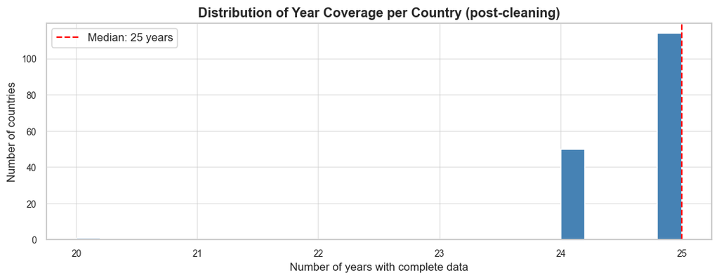

```
Countries with full 25-year coverage (2000–2024): 114
Countries with < 10 years of data: 0
```

```python
# ── 7.4 Coverage heatmap: how many years of data per country ────────────────
coverage = (df_clean.groupby('country')['year']
            .count()
            .sort_values(ascending=False))

fig, ax = plt.subplots(figsize=(10, 4))
ax.hist(coverage.values, bins=25, color='steelblue', edgecolor='white')
ax.axvline(coverage.median(), color='red', linestyle='--',
           label=f'Median: {coverage.median():.0f} years')
ax.set_title('Distribution of Year Coverage per Country (post-cleaning)', fontweight='bold')
ax.set_xlabel('Number of years with complete data')
ax.set_ylabel('Number of countries')
ax.legend()
plt.tight_layout()
plt.show()

print(f"Countries with full 25-year coverage (2000–2024): {(coverage == 25).sum()}")
print(f"Countries with < 10 years of data: {(coverage < 10).sum()}")
```

## Step 8: Univariate Analysis

**Rationale:** Before comparing groups, we examine each variable independently to understand its distribution. Economic variables (GDP, emissions) are typically right-skewed — a small number of large economies dominate. This affects which statistical methods and chart scales are appropriate later.

**What we check per variable:**

- Distribution shape (histogram + KDE)
- Central tendency (mean vs median — divergence indicates skew)
- Spread and outliers (boxplot)

> **Gap in Makai's notebook:** No univariate analysis was performed — the notebook jumped directly from cleaning to correlation and group comparison.

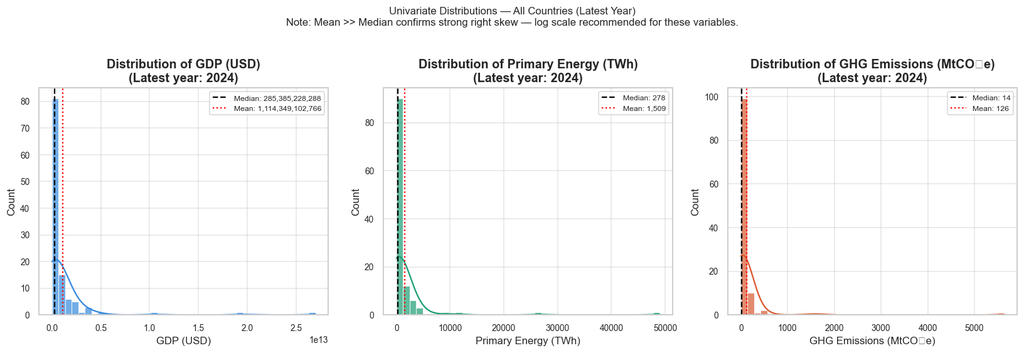

```python
# ── Distributions — latest year snapshot ────────────────────────────────────
latest_year = df_clean['year'].max()
df_latest   = df_clean[df_clean['year'] == latest_year].copy()

fig, axes = plt.subplots(1, 3, figsize=(15, 5))

plot_config = {
    'gdp':                        ('GDP (USD)', '#378ADD'),
    'primary_energy_consumption': ('Primary Energy (TWh)', '#1D9E75'),
    'greenhouse_gas_emissions':   ('GHG Emissions (MtCO₂e)', '#D85A30'),
}

for ax, (col, (label, color)) in zip(axes, plot_config.items()):
    data = df_latest[col].dropna()
    sns.histplot(data, bins=40, kde=True, ax=ax, color=color, alpha=0.7)
    ax.axvline(data.median(), color='black', linestyle='--', linewidth=1.5,
               label=f'Median: {data.median():,.0f}')
    ax.axvline(data.mean(), color='red', linestyle=':', linewidth=1.5,
               label=f'Mean: {data.mean():,.0f}')
    ax.set_title(f'Distribution of {label}\n(Latest year: {latest_year})', fontweight='bold')
    ax.set_xlabel(label)
    ax.legend(fontsize=8)

plt.suptitle(
    'Univariate Distributions — All Countries (Latest Year)\n'
    'Note: Mean >> Median confirms strong right skew — log scale recommended for these variables.',
    fontsize=11, y=1.02
)
plt.tight_layout()
plt.show()
```

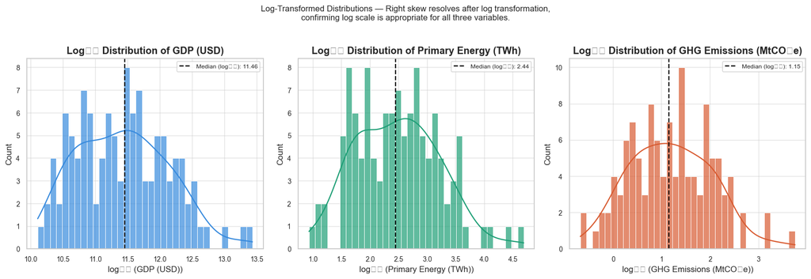

```python
# ── Log-transformed distributions (better for skewed economic data) ──────────
fig, axes = plt.subplots(1, 3, figsize=(15, 5))

for ax, (col, (label, color)) in zip(axes, plot_config.items()):
    data = np.log10(df_latest[col].dropna())
    sns.histplot(data, bins=35, kde=True, ax=ax, color=color, alpha=0.7)
    ax.axvline(data.median(), color='black', linestyle='--', linewidth=1.5,
               label=f'Median (log₁₀): {data.median():.2f}')
    ax.set_title(f'Log₁₀ Distribution of {label}', fontweight='bold')
    ax.set_xlabel(f'log₁₀ ({label})')
    ax.legend(fontsize=8)

plt.suptitle(
    'Log-Transformed Distributions — Right skew resolves after log transformation,\n'
    'confirming log scale is appropriate for all three variables.',
    fontsize=11, y=1.02
)
plt.tight_layout()
plt.show()
```

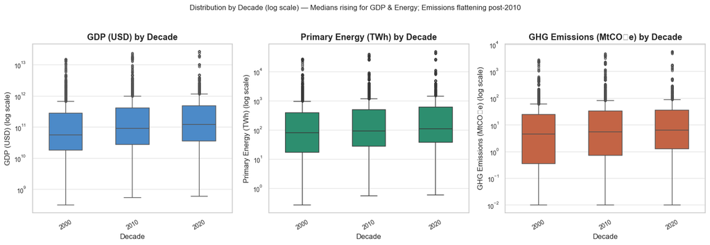

```python
# ── Boxplots by decade ───────────────────────────────────────────────────────
df_clean['decade'] = (df_clean['year'] // 10) * 10

fig, axes = plt.subplots(1, 3, figsize=(15, 5))

for ax, (col, (label, color)) in zip(axes, plot_config.items()):
    sns.boxplot(data=df_clean, x='decade', y=col, ax=ax,
                color=color, width=0.5, flierprops={'markersize': 3})
    ax.set_yscale('log')
    ax.set_title(f'{label} by Decade', fontweight='bold')
    ax.set_xlabel('Decade')
    ax.set_ylabel(f'{label} (log scale)')
    ax.tick_params(axis='x', rotation=30)

plt.suptitle('Distribution by Decade (log scale) — Medians rising for GDP & Energy; Emissions flattening post-2010',
             fontsize=11, y=1.02)
plt.tight_layout()
plt.show()
```

## Step 9: Bivariate & Relationship Analysis

**Rationale:** With distributions understood, we now examine pairwise relationships to answer **RQ1**: *Is there a statistically significant positive relationship between GDP, energy consumption, and emissions?*

We use:

- **Scatter plots with trend lines** (log-log scale — standard for economic relationships)
- **Time colour-coding** — to detect if the relationship has changed over the 2000–2024 period (i.e. are countries decoupling?)

**Year colour-coding interpretation:** If later years (yellow) cluster below the trend line in the GDP-vs-emissions chart, it suggests richer countries are starting to decouple economic growth from emissions — a key policy signal.

> **Fix from Makai's notebook:** Cell 24 referenced `df_plot` which was **never defined** — a broken variable reference that would cause a `NameError` at runtime. Fixed here.

```python
# ── Build df_plot (fix for Makai's undefined variable bug) ─────────────────
# Use the full cleaned dataset, drop any remaining NaN in plotting columns
df_plot = df_clean[['country', 'year'] + TRIO].dropna().copy()
print(f"df_plot rows: {len(df_plot):,}  |  Countries: {df_plot['country'].nunique()}")
```

```
df_plot rows: 4,070  |  Countries: 165
```

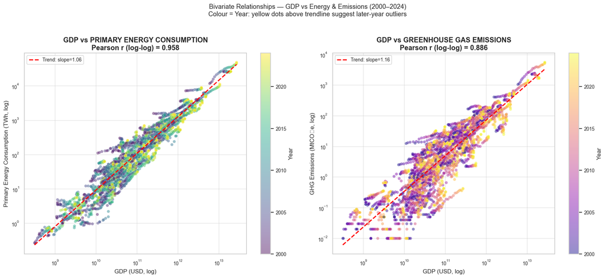

```python
# ── GDP vs Energy & GDP vs Emissions — scatter with trend line ──────────────
fig, axes = plt.subplots(1, 2, figsize=(16, 7))

pairs_to_plot = [
    ('gdp', 'primary_energy_consumption',
     'GDP (USD, log)', 'Primary Energy Consumption (TWh, log)', 'viridis'),
    ('gdp', 'greenhouse_gas_emissions',
     'GDP (USD, log)', 'GHG Emissions (MtCO₂e, log)', 'plasma'),
]

for ax, (xcol, ycol, xlabel, ylabel, cmap) in zip(axes, pairs_to_plot):
    sc = ax.scatter(df_plot[xcol], df_plot[ycol],
                    c=df_plot['year'], cmap=cmap,
                    alpha=0.45, s=30, edgecolors='white', linewidth=0.3)
    ax.set_xscale('log')
    ax.set_yscale('log')
    ax.set_xlabel(xlabel)
    ax.set_ylabel(ylabel)

    # OLS trend line on log-log scale
    lx = np.log10(df_plot[xcol])
    ly = np.log10(df_plot[ycol])
    mask = np.isfinite(lx) & np.isfinite(ly)
    z = np.polyfit(lx[mask], ly[mask], 1)
    p = np.poly1d(z)
    x_range = np.linspace(lx[mask].min(), lx[mask].max(), 200)
    ax.plot(10**x_range, 10**p(x_range), 'r--', linewidth=2,
            label=f'Trend: slope={z[0]:.2f}')
    ax.legend(fontsize=9)

    r_val = np.corrcoef(np.log10(df_plot[xcol][mask]), np.log10(df_plot[ycol][mask]))[0,1]
    ax.set_title(f'{xcol.upper().replace("_"," ")} vs {ycol.upper().replace("_"," ")}\n'
                 f'Pearson r (log-log) = {r_val:.3f}', fontweight='bold')
    plt.colorbar(sc, ax=ax, label='Year')

plt.suptitle('Bivariate Relationships — GDP vs Energy & Emissions (2000–2024)\n'
             'Colour = Year: yellow dots above trendline suggest later-year outliers',
             fontsize=12, y=1.02)
plt.tight_layout()
plt.show()
```

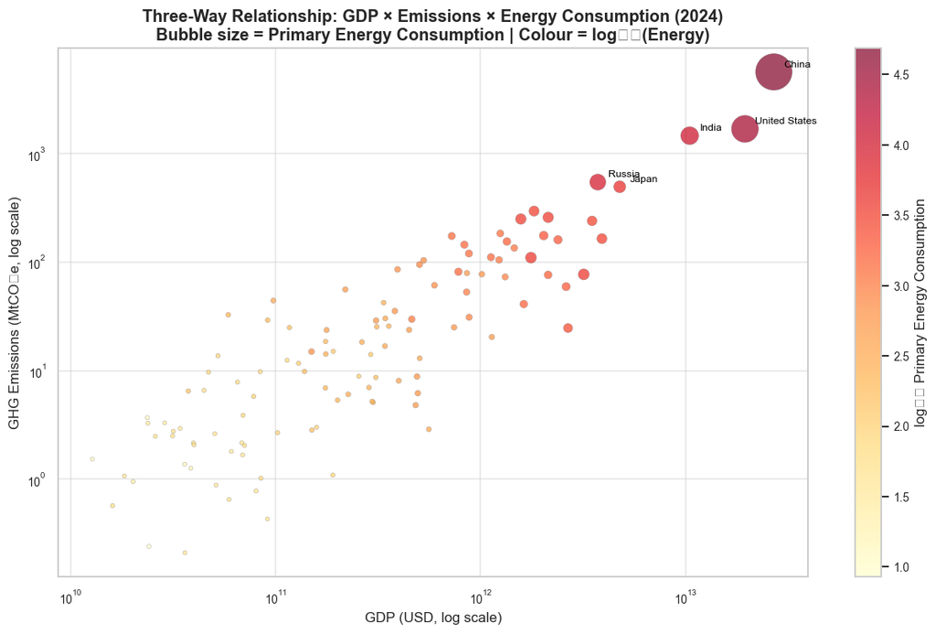

```python
# ── Three-way scatter: GDP, Energy, Emissions simultaneously ────────────────
# Bubble chart: x=GDP, y=Emissions, bubble size=Energy, colour=year
df_latest_plot = df_clean[df_clean['year'] == latest_year].dropna(subset=TRIO).copy()

# Normalise bubble size for plotting
size_norm = (df_latest_plot['primary_energy_consumption'] /
             df_latest_plot['primary_energy_consumption'].max() * 800 + 10)

fig, ax = plt.subplots(figsize=(11, 7))
sc = ax.scatter(df_latest_plot['gdp'],
                df_latest_plot['greenhouse_gas_emissions'],
                s=size_norm,
                c=np.log10(df_latest_plot['primary_energy_consumption']),
                cmap='YlOrRd', alpha=0.7, edgecolors='grey', linewidth=0.3)

ax.set_xscale('log')
ax.set_yscale('log')
ax.set_xlabel('GDP (USD, log scale)')
ax.set_ylabel('GHG Emissions (MtCO₂e, log scale)')
ax.set_title(f'Three-Way Relationship: GDP × Emissions × Energy Consumption ({latest_year})\n'
             'Bubble size = Primary Energy Consumption | Colour = log₁₀(Energy)',
             fontweight='bold')
plt.colorbar(sc, ax=ax, label='log₁₀ Primary Energy Consumption')

# Annotate top 5 emitters
top5 = df_latest_plot.nlargest(5, 'greenhouse_gas_emissions')
for _, row in top5.iterrows():
    ax.annotate(row['country'],
                xy=(row['gdp'], row['greenhouse_gas_emissions']),
                xytext=(8, 4), textcoords='offset points', fontsize=8, color='black')
plt.tight_layout()
plt.show()
```

## Step 10: Group Comparison — Top 10 vs Bottom 10 GDP Countries

**Rationale:** This addresses **RQ2**: *Do the top 10 highest-GDP countries show a different emissions-to-energy trend compared to the bottom 10?*

**Method:** We rank countries by their **average GDP across 2000–2024** (not a single-year snapshot, which could be biased by a crisis year). Countries are then grouped as Top 10 or Bottom 10, and we compare their distributions and time-series trends for all three variables.

**Why average GDP instead of a single year?** A country may have an unusual GDP in any given year (oil boom, financial crisis). The 25-year average is a more stable measure of economic standing.

> **Makai's notebook was correct on this logic.** Added here with additional chart types: time-series trend lines and a normalised emissions-intensity view.

```python
# ── Rank countries by average GDP (2000–2024) ───────────────────────────────
avg_df = (df_clean
          .groupby('country')[TRIO]
          .mean()
          .reset_index())

top_10_countries    = avg_df.nlargest(10,  'gdp')['country'].tolist()
bottom_10_countries = avg_df.nsmallest(10, 'gdp')['country'].tolist()

print("Top 10 GDP Countries (avg 2000–2024):")
print(top_10_countries)
print()
print("Bottom 10 GDP Countries (avg 2000–2024):")
print(bottom_10_countries)
```

```
Top 10 GDP Countries (avg 2000–2024):
['United States', 'China', 'India', 'Japan', 'Germany', 'Russia', 'Brazil', 'France', 'Indonesia', 'United Kingdom']

Bottom 10 GDP Countries (avg 2000–2024):
['Sao Tome and Principe', 'Dominica', 'Comoros', 'Saint Lucia', 'Seychelles', 'Djibouti', 'Guinea-Bissau', 'Cape Verde', 'Gambia', 'Liberia']
```

```python
# ── Build grouped DataFrame ──────────────────────────────────────────────────
df_grouped = df_clean.copy()
df_grouped['group'] = np.where(
    df_grouped['country'].isin(top_10_countries), 'Top 10 GDP',
    np.where(df_grouped['country'].isin(bottom_10_countries), 'Bottom 10 GDP', 'Other')
)
df_box = df_grouped[df_grouped['group'].isin(['Top 10 GDP', 'Bottom 10 GDP'])].copy()

print(f"Top 10 group rows    : {(df_box['group']=='Top 10 GDP').sum()}")
print(f"Bottom 10 group rows : {(df_box['group']=='Bottom 10 GDP').sum()}")
```

```
Top 10 group rows    : 250
Bottom 10 group rows : 240
```

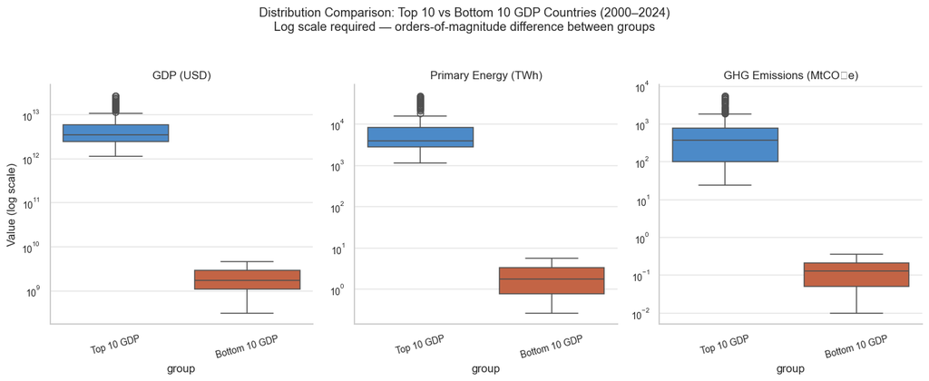

```python
# ── Faceted boxplots: all three variables side by side ───────────────────────
melted_box = df_box.melt(
    id_vars=['country', 'year', 'group'],
    value_vars=TRIO,
    var_name='Variable', value_name='Value'
)

label_map = {
    'gdp': 'GDP (USD)',
    'primary_energy_consumption': 'Primary Energy (TWh)',
    'greenhouse_gas_emissions': 'GHG Emissions (MtCO₂e)'
}
melted_box['Variable'] = melted_box['Variable'].map(label_map)

g = sns.FacetGrid(melted_box, col='Variable', sharey=False, height=5, aspect=0.85)
g.map_dataframe(sns.boxplot, x='group', y='Value',
                palette={'Top 10 GDP': '#378ADD', 'Bottom 10 GDP': '#D85A30'},
                order=['Top 10 GDP', 'Bottom 10 GDP'])
g.set(yscale='log')
g.set_ylabels('Value (log scale)')
g.set_titles('{col_name}')
g.set_xticklabels(rotation=15)
g.figure.suptitle('Distribution Comparison: Top 10 vs Bottom 10 GDP Countries (2000–2024)\n'
                   'Log scale required — orders-of-magnitude difference between groups',
                   y=1.03, fontsize=12)
plt.tight_layout()
plt.show()
```

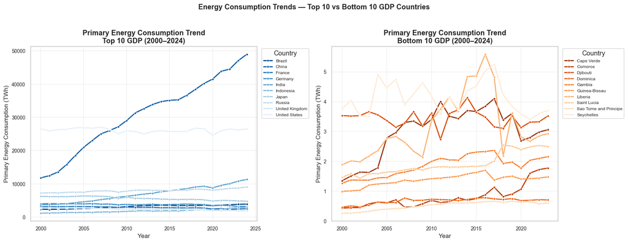

```python
# ── Time-series trend lines: energy consumption ──────────────────────────────
fig, axes = plt.subplots(1, 2, figsize=(16, 6))

for ax, group_name, palette in zip(axes,
                                    ['Top 10 GDP', 'Bottom 10 GDP'],
                                    ['Blues_r', 'Oranges_r']):
    sub = df_box[df_box['group'] == group_name]
    sns.lineplot(data=sub, x='year', y='primary_energy_consumption',
                 hue='country', marker='o', markersize=4, linewidth=2,
                 palette=palette, ax=ax, legend='full')
    ax.set_title(f'Primary Energy Consumption Trend\n{group_name} (2000–2024)',
                 fontweight='bold')
    ax.set_xlabel('Year')
    ax.set_ylabel('Primary Energy Consumption (TWh)')
    ax.legend(bbox_to_anchor=(1.01, 1), loc='upper left', fontsize=8, title='Country')
    ax.grid(True, alpha=0.3)

plt.suptitle('Energy Consumption Trends — Top 10 vs Bottom 10 GDP Countries',
             fontsize=13, fontweight='bold', y=1.02)
plt.tight_layout()
plt.show()
```

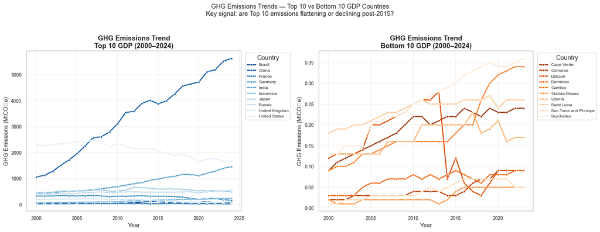

```python
# ── Time-series: greenhouse gas emissions ────────────────────────────────────
fig, axes = plt.subplots(1, 2, figsize=(16, 6))

for ax, group_name, palette in zip(axes,
                                    ['Top 10 GDP', 'Bottom 10 GDP'],
                                    ['Blues_r', 'Oranges_r']):
    sub = df_box[df_box['group'] == group_name]
    sns.lineplot(data=sub, x='year', y='greenhouse_gas_emissions',
                 hue='country', marker='o', markersize=4, linewidth=2,
                 palette=palette, ax=ax, legend='full')
    ax.set_title(f'GHG Emissions Trend\n{group_name} (2000–2024)',
                 fontweight='bold')
    ax.set_xlabel('Year')
    ax.set_ylabel('GHG Emissions (MtCO₂e)')
    ax.legend(bbox_to_anchor=(1.01, 1), loc='upper left', fontsize=8, title='Country')
    ax.grid(True, alpha=0.3)

plt.suptitle('GHG Emissions Trends — Top 10 vs Bottom 10 GDP Countries\n'
             'Key signal: are Top 10 emissions flattening or declining post-2015?',
             fontsize=12, y=1.02)
plt.tight_layout()
plt.show()
```

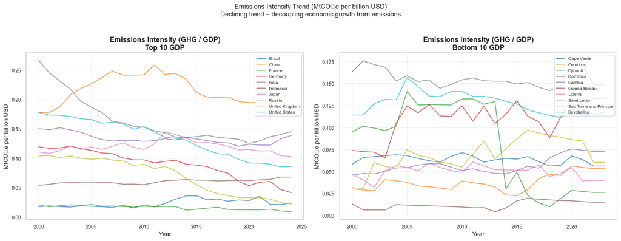

```python
# ── Emissions intensity: GHG per unit of GDP (efficiency metric) ─────────────
# This is the decoupling indicator — lower = more emissions-efficient economy
df_box['emissions_per_gdp'] = (df_box['greenhouse_gas_emissions'] /
                                df_box['gdp'] * 1e9)  # MtCO2e per billion USD

fig, axes = plt.subplots(1, 2, figsize=(16, 6))

for ax, group_name, color in zip(axes,
                                  ['Top 10 GDP', 'Bottom 10 GDP'],
                                  ['#185FA5', '#993C1D']):
    sub = df_box[df_box['group'] == group_name]
    country_avg = sub.groupby(['country', 'year'])['emissions_per_gdp'].mean().reset_index()
    for country in country_avg['country'].unique():
        data = country_avg[country_avg['country'] == country]
        ax.plot(data['year'], data['emissions_per_gdp'],
                linewidth=1.5, alpha=0.7, label=country)
    ax.set_title(f'Emissions Intensity (GHG / GDP)\n{group_name}', fontweight='bold')
    ax.set_xlabel('Year')
    ax.set_ylabel('MtCO₂e per billion USD')
    ax.legend(fontsize=8, loc='upper right')
    ax.grid(True, alpha=0.3)

plt.suptitle('Emissions Intensity Trend (MtCO₂e per billion USD)\n'
             'Declining trend = decoupling economic growth from emissions',
             fontsize=12, y=1.02)
plt.tight_layout()
plt.show()
```

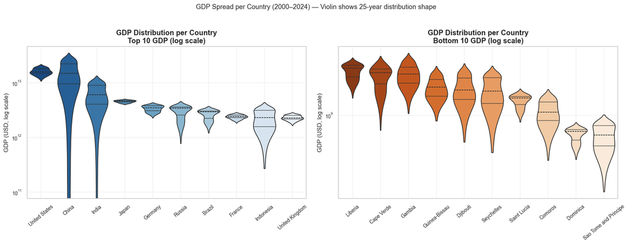

```python
# ── Violin plots: per-country GDP spread within each group ──────────────────
fig, axes = plt.subplots(1, 2, figsize=(16, 6))

for ax, group_name, palette in zip(axes,
                                    ['Top 10 GDP', 'Bottom 10 GDP'],
                                    ['Blues_r', 'Oranges_r']):
    sub = df_box[df_box['group'] == group_name]
    country_order = (sub.groupby('country')['gdp']
                     .median()
                     .sort_values(ascending=False)
                     .index.tolist())
    sns.violinplot(data=sub, x='country', y='gdp',
                   order=country_order, palette=palette, ax=ax, inner='quartile')
    ax.set_yscale('log')
    ax.tick_params(axis='x', rotation=40)
    ax.set_title(f'GDP Distribution per Country\n{group_name} (log scale)',
                 fontweight='bold')
    ax.set_xlabel('')
    ax.set_ylabel('GDP (USD, log scale)')
    ax.grid(True, alpha=0.3)

plt.suptitle('GDP Spread per Country (2000–2024) — Violin shows 25-year distribution shape',
             fontsize=12, y=1.02)
plt.tight_layout()
plt.show()
```